# Quantification of Weight Lifting Action

Jimmy Iskandar

Monday, August 24, 2014

## Executive Summary

A group of six health participants were requested to perform weight lifting exercises in five different ways, where one way is the correct one, while the other four ways are incorrect. The participants are connected to Microsoft Kinnect sensors. Our task is to predict how well the participants perform the weight lifting exercises using data from accelerometers on the belt, forearm, arm, and dumbell.

- Inclusion of all participants
- Inclusion of all five ways for each participant
- For each participant and each way, divide the data into D segments and take 60% of each segment for training (while the remaining 40% for testing)

We notice that prediction accuracy increases significantly as we increase D, the number of k-fold cross validation has little impact to the prediction accuracy, and the number of trees has a medium impact to the accuracy. In regard to pre-processing, center and scale each participant, so no pre-processing is performed. Interestingly, we also find that bagging doesn’t improve the prediction accuracy. In the case of cross-validation, we take advantage the caret’s cross-validation framework which optimizes the internal parameters of Random Forest and provides a nice summary of its accuracy/error for each fold.

## Analysis

First, we load the data. To view the data over time, we add timestamp part 1 and part 2.

```r
# load the training data
dat <- read.csv("pml-training.csv")
dat <- dat[,-1]

# get the timestamp
dat$time <- dat$raw_timestamp_part_1 + dat$raw_timestamp_part_2

# load data for prediction assignment
testdat <- read.csv("pml-testing.csv")
testdat <- testdat[,-1]
```

We plot a sensor over time for all participants. Each participant operates on a different operating regime. Other sensors also show similar behavior. This leads to think that we should center and scale the data for each participant. However, it doesn’t help the prediction accuracy. Random forest automatically takes care this situation.

```r
library(caret)
```

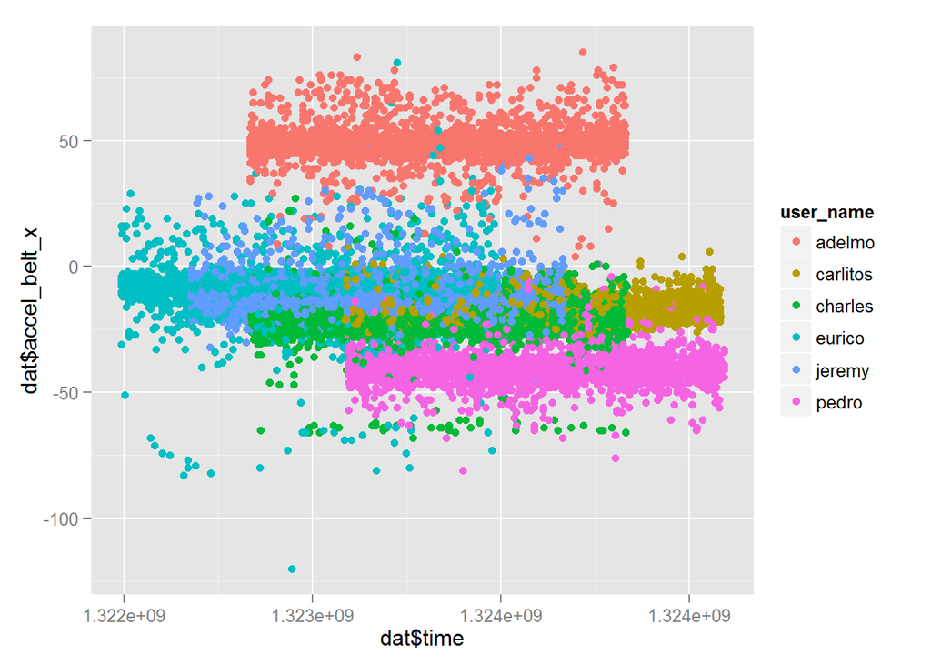

```r
qplot(dat$time,dat$accel_belt_x,colour=user_name,data=dat)
```

To view the data more up-close, we plot a sensor over time for one participant. There is no noticeable trend over time. The variance seems to stay constant, thus there is no apparent need for transformation, such as, BoxCox transform. Other sensors exhibit similar behavior.

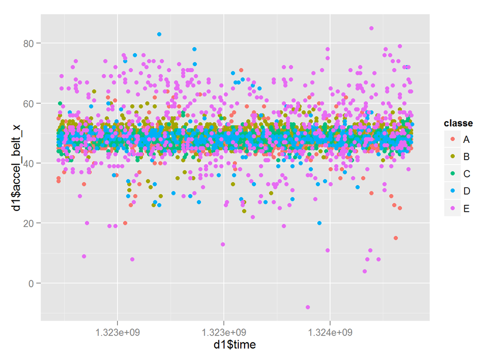

```r
u1 <- grep("adelmo",dat$user_name)
d1 <- dat[u1,]
qplot(d1$time,d1$accel_belt_x,colour=classe,data=d1)
```

Below only accelerometer-related sensors are used and sensors with many NAs are removed.

```r
# get indices of all accel-related variables
aci = grep("accel",colnames(dat))

# count the number of NAs for each accel variable
nac = apply(dat[,aci],2,function(x){ length(which(is.na(x)))})

# find which variables to exclude (the ones which have more tha 20% NAs)
exi = which(nac/nrow(dat) > 0.2)

# set the input (x) and output (y)
x <- dat[,aci[-exi]]
y <- dat$classe

# this is for prediction assignment
testx <- testdat[,aci[-exi]]
```

This is the list of sensors.

```r
colnames(x)
```

```
##  [1] "total_accel_belt"     "accel_belt_x"         "accel_belt_y"
##  [4] "accel_belt_z"         "total_accel_arm"      "accel_arm_x"
##  [7] "accel_arm_y"          "accel_arm_z"          "total_accel_dumbbell"
## [10] "accel_dumbbell_x"     "accel_dumbbell_y"     "accel_dumbbell_z"
## [13] "total_accel_forearm"  "accel_forearm_x"      "accel_forearm_y"
## [16] "accel_forearm_z"
```

This is a code to construct the training set. This is the psedocode:

- For each participant and for each way,
- Divide the data into D segments
- For each segment, use the first 60% as training and the remaining 40% for testing

The code also contains a commented section to scaling and centering each participant, which doesn’t help the prediction result. For brevity, we don’t show accompanying results.

```r
D <- 10 # the number of segments per participant and way
TrainPct <- 0.6 # 60% for training
traini <- c()
names <- unique(dat$user_name)
classes <- unique(dat$classe)
xn <- x # centered and scaled x, we end up using x only
testxn <- testx # this is for prediction assignment

# loop over participants
for(n in names) {
  i <- grep(n,dat$user_name)
  testi <- grep(n,testdat$user_name)
  classes <- unique(dat$classe[i])
  ti <- c()

  # loop over ways
  for(c in classes) {
    j <- grep(c,dat$classe[i])
    len <- length(j)
    sz <- len/D

    # loop over segments
    for(s in 1:D) {
      start  <- (s-1)*sz + 1
      end <- start + sz*TrainPct
      ti <- c(ti,i[j[start]:j[end]])
    }
  }

  meant <- colMeans(x[ti,])
  sdt <- apply(x[ti,],2,sd)

  # center and scale each participant apparently doesn't help
  # xn[i,] <- (x[i,]-meant)/sdt
  xn[i,] <- x[i,]
  traini <- c(traini,ti)

  # center and scale each participant apparently doesn't help
  # testxn[i,] <- (testx[i,]-meant)/sdt
  testxn[i,] <- testx[i,]
}

# get the training and testing matrix
train <- cbind(y[traini],xn[traini,])
trainc <- train[complete.cases(train),] # remove incomplete rows
test <- cbind(y[-traini],xn[-traini,])
testc <- test[complete.cases(test),] # remove incomplete rows
colnames(trainc)[1] <- "classe"
colnames(testc)[1] <- "classe"

training <- trainc
testing <- testc
```

This is a note for somethings we have tried: PCA and BoxCox don’t help. For brevity, we don’t provide accompanying results.

```r
# Preprocessing with PCA doesn't help
#
# preProc <- preProcess(trainc[,-1],method="pca",pcaComp=5)
# trainPC <- predict(preProc,trainc[,-1])
# testPC <- predict(preProc,testc[,-1])
#
# training <- cbind(trainc$classe,trainPC)
# testing <- cbind(testc$classe,testPC)
# colnames(training)[1] <- "classe"
# colnames(testing)[1] <- "classe"

# Preprocessing with BoxCox doesn't help
# preObj <- preProcess(trainc[,-1],method=c("BoxCox"))
# trainBC <- predict(preObj,trainc[,-c(1)])
# testBC <- predict(preObj,testc[,-c(1)])
#
# training <- cbind(trainc$classe,trainBC)
# testing <- cbind(testc$classe,testBC)
# colnames(training)[1] <- "classe"
# colnames(testing)[1] <- "classe"
```

All sixteen accelometer sensors have considerable contributions, so we use them all in the model.

```r
fit <- train(factor(classe) ~ .,method="rf",data=training,importance=TRUE,replace=TRUE,trControl = trainControl(method="cv"),number=2,ntree=20)
v <-varImp(fit,useModel=T,scale=F)
v
```

```
## rf variable importance
##
##   variables are sorted by maximum importance across the classes
##                          A     B     C     D     E
## accel_forearm_x      11.76 13.51 14.25 17.83 13.34
## accel_dumbbell_y     13.95 14.04 15.60 17.05 13.57
## accel_arm_y           8.36 11.91 15.82 16.20 12.13
## accel_dumbbell_z      9.69 12.05 15.48 11.21 11.72
## total_accel_dumbbell 15.07 11.76 14.97 12.94 13.02
## accel_dumbbell_x      9.07 15.04 14.27 13.46 13.32
## accel_forearm_y       8.31 10.09 13.38 11.34 11.42
## accel_forearm_z      12.91 10.04 12.52 10.32  8.48
## accel_arm_x           8.86 10.40 10.65 12.53  9.02
## total_accel_arm       9.32 12.31 10.03 10.75  7.63
## accel_belt_z          8.06 12.25 11.77 10.52  8.94
## accel_arm_z           9.64 11.56 11.50 10.24  8.96
## accel_belt_x         11.11 11.34 11.49  7.55  8.53
## total_accel_forearm   7.72 10.64 11.03 10.17  7.49
## accel_belt_y          7.07  6.96  7.57 10.58 10.29
## total_accel_belt      6.45  6.45  5.89  7.92  6.83
```

From the previously trained model, we show the misclassification rate. Further, we experiment with the number of k-folds cross-validation and the number of trees. Note that we take advantage of the caret’s cross validation framework, which optimizes the internal parameters of Random Forest.

```r
missClass = function(values,prediction){length(which(prediction != values))/length(values)}
missClass(as.character(testing$classe),as.character(predict(fit,testing)))
```

```
## [1] 0.1711
```

```r
# increase the number of trees to 40
fit <- train(factor(classe) ~ .,method="rf",data=training,importance=TRUE,replace=TRUE,trControl = trainControl(method="cv"),number=2,ntree=40)
missClass = function(values,prediction){length(which(prediction != values))/length(values)}
missClass(as.character(testing$classe),as.character(predict(fit,testing)))
```

```
## [1] 0.1537
```

```r
# increase the number of k-fold CV to 10 folds
fit <- train(factor(classe) ~ .,method="rf",data=training,importance=TRUE,replace=TRUE,trControl = trainControl(method="cv"),number=10,ntree=40)
missClass = function(values,prediction){length(which(prediction != values))/length(values)}
missClass(as.character(testing$classe),as.character(predict(fit,testing)))
```

```
## [1] 0.1569
```

From experimentation, we settle with 10-fold CV, 100 number of trees and D (number of segments) = 160. This provides 5% misclassification rate, hence 95% prediction accuracy on the testing (out of samples) data.

```r
D <- 160 # the number of segments per participant and way
TrainPct <- 0.6 # 60% for training
traini <- c()
names <- unique(dat$user_name)
classes <- unique(dat$classe)
xn <- x # centered and scaled x, we end up using x only
testxn <- testx # this is for prediction assignment

# loop over participants
for(n in names) {
  i <- grep(n,dat$user_name)
  testi <- grep(n,testdat$user_name)
  classes <- unique(dat$classe[i])
  ti <- c()

  # loop over ways
  for(c in classes) {
    j <- grep(c,dat$classe[i])
    len <- length(j)
    sz <- len/D

    # loop over segments
    for(s in 1:D) {
      start  <- (s-1)*sz + 1
      end <- start + sz*TrainPct
      ti <- c(ti,i[j[start]:j[end]])
    }
  }

  meant <- colMeans(x[ti,])
  sdt <- apply(x[ti,],2,sd)

  # center and scale each participant apparently doesn't help
  # xn[i,] <- (x[i,]-meant)/sdt
  xn[i,] <- x[i,]
  traini <- c(traini,ti)

  # center and scale each participant apparently doesn't help
  # testxn[i,] <- (testx[i,]-meant)/sdt
  testxn[i,] <- testx[i,]
}

# get the training and testing matrix
train <- cbind(y[traini],xn[traini,])
trainc <- train[complete.cases(train),] # remove incomplete rows
test <- cbind(y[-traini],xn[-traini,])
testc <- test[complete.cases(test),] # remove incomplete rows
colnames(trainc)[1] <- "classe"
colnames(testc)[1] <- "classe"

training <- trainc
testing <- testc

fit <- train(factor(classe) ~ .,method="rf",data=training,importance=TRUE,replace=TRUE,trControl = trainControl(method="cv"),number=10,ntree=100)

missClass = function(values,prediction){length(which(prediction != values))/length(values)}
missClass(as.character(testing$classe),as.character(predict(fit,testing)))
```

```
## [1] 0.04469
```

This is the description of the fit and its cross-validation accuracy on each fold.

```r
fit
```

```
## Random Forest
##
## 16467 samples
##    16 predictors
##     5 classes: 'A', 'B', 'C', 'D', 'E'
##
## No pre-processing
## Resampling: Cross-Validated (10 fold)
##
## Summary of sample sizes: 14819, 14819, 14821, 14820, 14821, 14822, ...
##
## Resampling results across tuning parameters:
##
##   mtry  Accuracy  Kappa  Accuracy SD  Kappa SD
##   2     0.9       0.9    0.004        0.005
##   9     0.9       0.9    0.007        0.009
##   20    0.9       0.9    0.005        0.007
##
## Accuracy was used to select the optimal model using  the largest value.
## The final value used for the model was mtry = 2.
```

```r
fit$resample
```

```
##    Accuracy  Kappa Resample
## 1    0.9521 0.9397   Fold02
## 2    0.9539 0.9421   Fold01
## 3    0.9405 0.9252   Fold03
## 4    0.9447 0.9305   Fold06
## 5    0.9447 0.9305   Fold05
## 6    0.9454 0.9313   Fold04
## 7    0.9502 0.9374   Fold07
## 8    0.9502 0.9374   Fold10
## 9    0.9502 0.9375   Fold09
## 10   0.9441 0.9298   Fold08
```

This is the code for creating prediction assigment submission files.

```r
# submit <- predict(fit,testxn)
#
# pml_write_files = function(x){
#   n = length(x)
#   for(i in 1:n){
#     filename = paste0("problem_id_",i,".txt")
#     write.table(x[i],file=filename,quote=FALSE,row.names=FALSE,col.names=FALSE)
#   }
# }
#
# pml_write_files(submit)
```

Below is the code for bagging. It is extremely time consuming and the result doesn’t improve.

```r
# create 10 models
# N = 10
# fitl <- vector("list",N)
# for(i in 1:N){
#   ss <- sample(1:dim(trainc)[1],replace=T)
#   fitl[[i]] <- train(factor(classe) ~ .,method="rf",data=training[ss,],ntree=100,importance=TRUE,replace=TRUE,trControl = trainControl(method="cv"),number=10,ntree=100)
# }
#
# # do prediction
# ll <- matrix(NA,nrow=dim(testing)[1],ncol=N)
# for(i in 1:N) {
#   ll[,i] <- predict(fitl[[i]],testing)
# }
#
# # do voting by counting the winner way
# llcount <- matrix(NA,nrow=nrow(ll),ncol=length(classes))
# for(i in 1:nrow(ll))
#     llcount[i,] <- sapply(classes,function(x) length(which(ll[i,]==rep(as.numeric(x),ncol(ll)))))
#
# # get the winner list
# llresult <- apply(llcount,1,function(x) which(x==max(x)))
# result <- vector("numeric",length(llresult))
# for(i in 1:length(llresult)) result[i] = as.numeric(unlist(llresult[i]))
#
# # get misclassification rate
# missClass(as.numeric(testing$classe),result)
```

## Reference

Velloso, E.; Bulling, A.; Gellersen, H.; Ugulino, W.; Fuks, H. [Qualitative Activity Recognition of Weight Lifting Exercises] (http://groupware.les.inf.puc-rio.br/work.jsf?p1=11201). Proceedings of 4th International Conference in Cooperation with SIGCHI (Augmented Human ’13) . Stuttgart, Germany: ACM SIGCHI, 2013.